# Trabajo1_Ejemplo2

Laura Romero Roldán

3/11/2021

```r
source("teoriadecision_funciones_incertidumbre.R", encoding = "UTF-8")
source("teoriadecision_funciones_trabajo1.R", encoding = "UTF-8")
```

Un empresario está tratando de decidir qué tipo de calzado fabricar para el próximo año, teniendo en cuenta que la temperatura pasa por sus 3 estados a lo largo de todo el año (Frío, Normal, Cálido). Tiene las siguientes opciones:

• Botas, los beneficios depende de la temperatura, si la temperatura es fría obtendrá aproximadamente 60000€, si es normal 15000€ y si es cálida, los beneficios disminuirán a 2500€

• Zapatos, si la temperatura es fría obtendrá aproximadamente 5000€, si es normal 30000€ y si es cálida 10000€

• Sandalias, si la temperatura es fría obtendrá una pérdida de 5000€, si es normal los beneficios serán 7500€ y si es cálida 50000€

¿Qué tipo de calzado le recomienda usted, si su objetivo es maximizar los beneficios?

**Planteamiento**

- Un decisor
- Modelo de beneficios (favorable)
- Alternativas:
  - d1 = “botas”
  - d2 = “zapatos”
  - d3 = “sandalias”
- Estados de la naturaleza:
  - e1 = “frío”
  - e2 = “normal”
  - e3 = “cálido”

**Introducción de datos**

```r
tbLaura = crea.tablaX(c(60,15,2.5,
                        5,30,10,
                        -5,7.5,50), numalternativas = 3, numestados = 3)

colnames(tbLaura)=c('Frío','Normal','Cálido')
rownames(tbLaura)=c('Botas','Zapatos','Sandalias')

tbLaura
```

```
##           Frío Normal Cálido
## Botas       60   15.0    2.5
## Zapatos      5   30.0   10.0
## Sandalias   -5    7.5   50.0
```

**Solución**

```r
criterio.Todos(tbLaura, alfa=0.3,favorable = TRUE)
```

```
##                 Frío Normal Cálido Wald Optimista Hurwicz Savage Laplace
## Botas             60   15.0    2.5  2.5        60   19.75   47.5   25.83
## Zapatos            5   30.0   10.0  5.0        30   12.50   55.0   15.00
## Sandalias         -5    7.5   50.0 -5.0        50   11.50   65.0   17.50
## iAlt.Opt (fav.) <NA>   <NA>   <NA>   d2        d1      d1     d1      d1
##                 Punto Ideal
## Botas                 49.81
## Zapatos               68.01
## Sandalias             68.78
## iAlt.Opt (fav.)          d1
```

Según el criterio de Wald la mejor alternativa es la 2 (Zapatos), y según los demás criterios la mejor alternativa es la 1 (Botas).

Vamos a ver ahora como varía el criterio de Hurwicz para los diferentes valores de alfa:

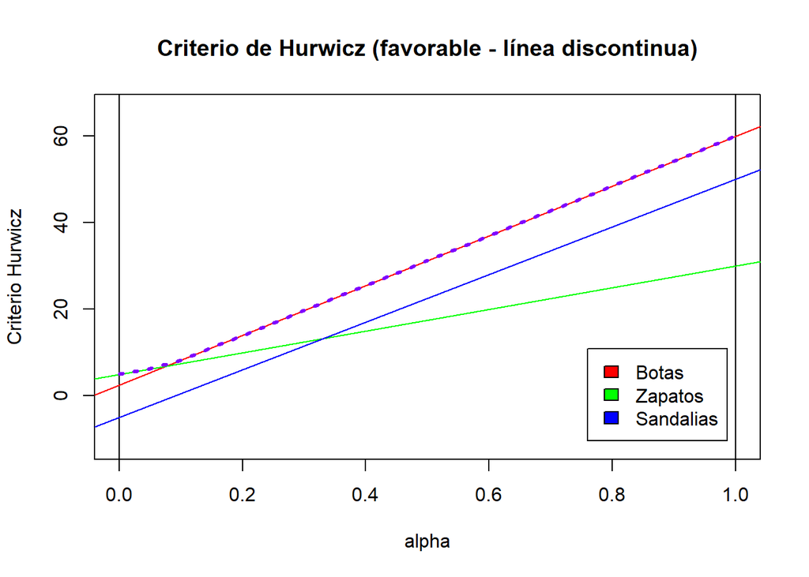

```r
dibuja.criterio.Hurwicz(tbLaura,favorable=TRUE)
```

```r
alfas(tbLaura,precisionAlfa = 0.05,favorable = TRUE)
```

```
## La mejor alternativa es 2 para alfa perteneciente a [ 0 , 0.1 ] y la mejor alternativa es 1 para alfa perteneciente a [ 0.1 , 1 ]
```

La mejor **alternativa es 2** para alfa perteneciente a [ 0 , 0.1 ] y la mejor **alternativa es 1** para alfa perteneciente a [ 0.1 , 1 ]

```r
alfas(tbLaura,precisionAlfa = 0.01,favorable = TRUE)
```

```
## La mejor alternativa es 2 para alfa perteneciente a [ 0 , 0.08 ] y la mejor alternativa es 1 para alfa perteneciente a [ 0.08 , 1 ]
```

La mejor **alternativa es 2** para alfa perteneciente a [ 0 , 0.08 ] y la mejor **alternativa es 1** para alfa perteneciente a [ 0.08 , 1 ]